# Part I - Loan Data

## Bivariate Exploration

> In this section, investigate relationships between pairs of variables in your data. Make sure the variables that you cover here have been introduced in some fashion in the previous section (univariate exploration).

### Question 1: How does Borrower APR relate to Loan Status?

### Visualization 1: Boxplot of Borrower APR for Different Loan Statuses

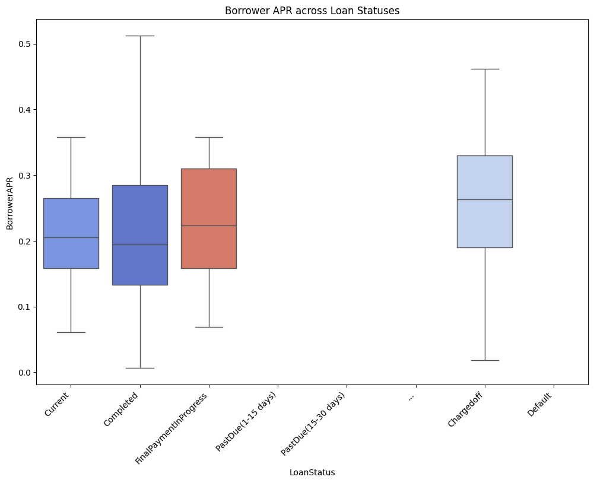

```python
# Create a boxplot to visualize the distribution of Borrower APR across different Loan Statuses
plt.figure(figsize=(12, 8))

# Order of LoanStatus categories for better visualization
loan_status_order = ['Current', 'Completed', 'FinalPaymentInProgress',
                     'PastDue(1-15 days)', 'PastDue(15-30 days)', '...',
                     'Chargedoff', 'Default']

# Generate a boxplot with specified parameters
sb.boxplot(data=prosper_loan_data,
           x='LoanStatus',  # X-axis represents Loan Status categories
           y='BorrowerAPR',  # Y-axis represents Borrower APR
           palette='coolwarm',  # Color palette for the plot
           showfliers=False,  # Do not display outliers for better focus
           hue='LoanStatus',  # Add color encoding based on Loan Status
           order=loan_status_order,  # Specify the order of categories on the x-axis
           legend=False)  # Do not display the legend for simplicity

# Set the title and labels for better interpretation
plt.title('Borrower APR across Loan Statuses')
plt.xticks(rotation=45, ha='right')  # Rotate x-axis labels for better readability

# Display the plot
plt.show()
```

### Observations:

- This boxplot helps visualize the distribution of Borrower APR for different loan statuses.
- The showfliers=False argument is added to exclude outliers from the plot.
- It provides insights into whether there are significant variations in Borrower APR based on the loan status.

### Question 2: Is there a relationship between Credit Grade and Borrower APR?

### Visualization 2: Violin Plot of Credit Grade vs. Borrower APR

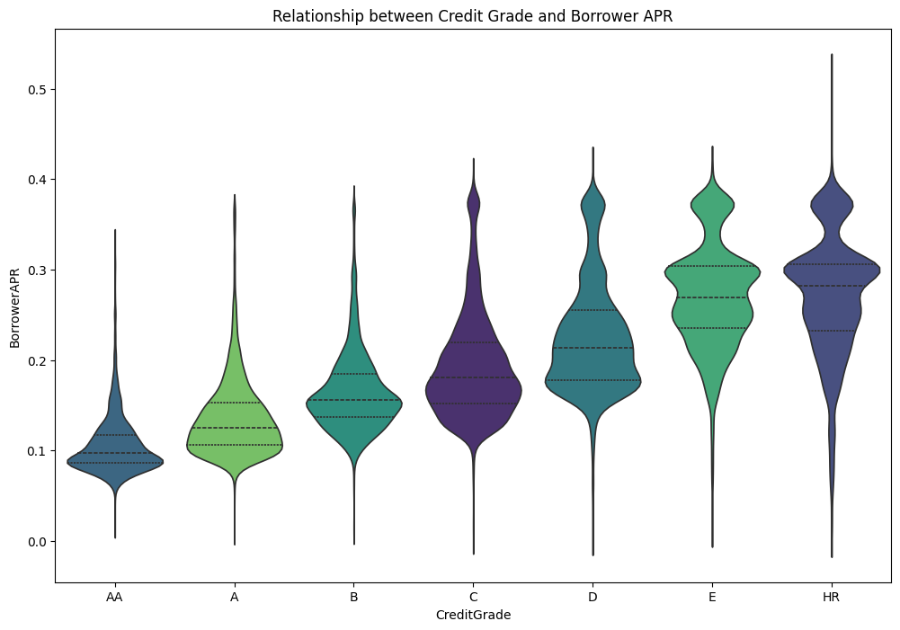

```python
# Create a violin plot to explore the relationship between Credit Grade and Borrower APR
plt.figure(figsize=(12, 8))

# Order of CreditGrade categories for better visualization
credit_grade_order = ['AA', 'A', 'B', 'C', 'D', 'E', 'HR']

# Generate a violin plot with specified parameters
sb.violinplot(data=prosper_loan_data,
              x='CreditGrade',  # X-axis represents Credit Grade categories
              y='BorrowerAPR',  # Y-axis represents Borrower APR
              palette='viridis',  # Color palette for the plot
              inner='quartile',  # Show quartiles inside the violin plot
              hue='CreditGrade',  # Add color encoding based on Credit Grade
              legend=False,  # Do not display the legend for simplicity
              order=credit_grade_order)  # Specify the order of categories on the x-axis

# Set the title for better interpretation
plt.title('Relationship between Credit Grade and Borrower APR')

# Display the plot
plt.show()
```

### Question 3: How does Loan Term affect Borrower Rate?

### Visualization 3: Boxplot of Loan Term vs. Borrower Rate

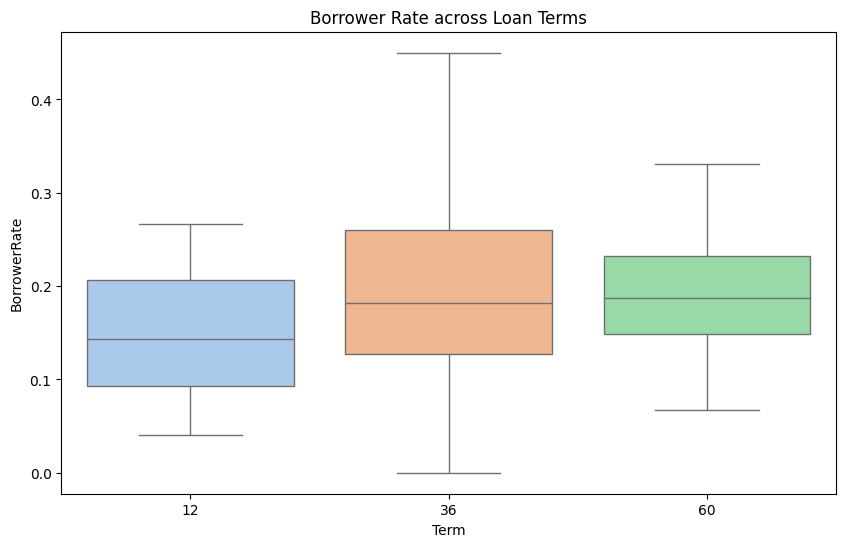

```python
# Create a box plot to explore the relationship between Borrower Rate and Loan Terms
plt.figure(figsize=(10, 6))

# Generate a box plot with specified parameters
sb.boxplot(data=prosper_loan_data,
           x='Term',  # X-axis represents Loan Terms
           y='BorrowerRate',  # Y-axis represents Borrower Rate
           palette='pastel',  # Color palette for the plot
           showfliers=False,  # Do not show outliers for clarity
           hue='Term',  # Add color encoding based on Loan Terms
           legend=False)  # Do not display the legend for simplicity

# Set the title for better interpretation
plt.title('Borrower Rate across Loan Terms')

# Display the plot
plt.show()
```

### Question 4: What is the relationship between Credit Grade and Loan Status?

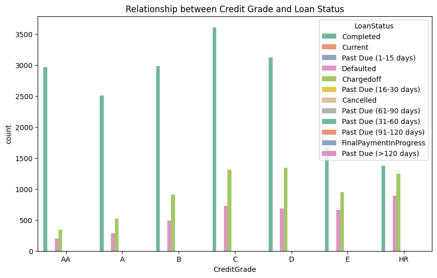

```python
# Order of CreditGrade categories
credit_grade_order = ['AA', 'A', 'B', 'C', 'D', 'E', 'HR']

# Credit Grade count plot with hue
create_count_plot(
    data=prosper_loan_data,  # Provide the dataset
    x='CreditGrade',  # Specify the column for x-axis
    hue='LoanStatus',  # Specify the column for color encoding
    palette='Set2',  # Specify the color palette
    title='Relationship between Credit Grade and Loan Status',  # Specify the title of the plot
    order=credit_grade_order  # Optionally specify the order of categories on the x-axis
)
```

### Question 5: How does Borrower Rate vary across different Loan Status categories?